# Tutorial of rgeoda v0.0.6

lixun910

1/6/2021

`rgeoda` is an R library for spatial data analysis. It is an R wrapper of the libgeoda C++ library, which is built based on the `GeoDa` software. The version used in this tutorial is version 0.0.6.

## 1. Install `rgeoda`

rgeoda will be submitted to CRAN soon. Once it is accepted, one should be able to install rgeoda in R console

```
install.packages("rgeoda")
```

### Load `rgeoda` library in R

If everything installed without error, you should be able to load `rgeoda`:

```r
library(rgeoda)
```

## 2. Load Spatial Data

The data formats that `rgeoda` can read directly includes ESRI Shapefile and Geojson (coming in next version).

For example, to load the ESRI Shapefile `Guerry.shp` comes with the package:

```r
guerry_path <- system.file("extdata", "Guerry.shp", package = "rgeoda")
guerry <- geoda_open(guerry_path)
```

The `geoda_open` function returns a `geoda` object, which can be used to access the meta-data, fields, and columns of the input dataset.

```r
guerry_df <- as.data.frame(guerry)
class(guerry_df)
```

```
## [1] "data.frame"
```

Now guerry_df is a data frame.

#### 2.1 Attributes of `geoda_df` dataframe

```r
head(guerry_df)
```

```
##      CODE_DE COUNT AVE_ID_ dept Region      Dprtmnt Crm_prs Crm_prp Litercy
## NA        01     1      49    1      E          Ain   28870   15890      37
## NA.1      02     1     812    2      N        Aisne   26226    5521      51
## NA.2      03     1    1418    3      C       Allier   26747    7925      13
## NA.3      04     1    1603    4      E Basses-Alpes   12935    7289      46
## NA.4      05     1    1802    5      E Hautes-Alpes   17488    8174      69
## NA.5      07     1    2249    7      S      Ardeche    9474   10263      27
##      Donatns Infants Suicids MainCty Wealth Commerc Clergy Crm_prn Infntcd
## NA      5098   33120   35039       2     73      58     11      71      60
## NA.1    8901   14572   12831       2     22      10     82       4      82
## NA.2   10973   17044  114121       2     61      66     68      46      42
## NA.3    2733   23018   14238       1     76      49      5      70      12
## NA.4    6962   23076   16171       1     83      65     10      22      23
## NA.5    3188   42117   52547       1     84       1     28      76      47
##      Dntn_cl Lottery Desertn Instrct Prsttts Distanc Area Pop1831 TopCrm TopLit
## NA        69      41      55      46      13 218.372 5762  346.03      1      0
## NA.1      36      38      82      24     327  65.945 7369  513.00      1      1
## NA.2      76      66      16      85      34 161.927 7340  298.26      1      0
## NA.3      37      80      32      29       2 351.399 6925  155.90      0      1
## NA.4      64      79      35       7       1 320.280 5549  129.10      0      1
## NA.5      67      70      19      62       1 279.413 5529  340.73      0      0
##      TopWealth
## NA           1
## NA.1         0
## NA.2         1
## NA.3         1
## NA.4         1
## NA.5         1
```

```r
ncol(guerry_df)
```

```
## [1] 29
```

```r
nrow(guerry_df)
```

```
## [1] 85
```

```r
names(guerry_df)
```

```
##  [1] "CODE_DE"   "COUNT"     "AVE_ID_"   "dept"      "Region"    "Dprtmnt"
##  [7] "Crm_prs"   "Crm_prp"   "Litercy"   "Donatns"   "Infants"   "Suicids"
## [13] "MainCty"   "Wealth"    "Commerc"   "Clergy"    "Crm_prn"   "Infntcd"
## [19] "Dntn_cl"   "Lottery"   "Desertn"   "Instrct"   "Prsttts"   "Distanc"
## [25] "Area"      "Pop1831"   "TopCrm"    "TopLit"    "TopWealth"
```

### 2.2 Access Table Data

Get data from first colum:

```r
guerry_df[,1]
```

```
##  [1] "01" "02" "03" "04" "05" "07" "08" "09" "10" "11" "12" "13" "14" "15" "16"
## [16] "17" "18" "19" "21" "22" "23" "24" "25" "26" "27" "28" "29" "30" "31" "32"
## [31] "33" "34" "35" "36" "37" "38" "39" "40" "41" "42" "43" "44" "45" "46" "47"
## [46] "48" "49" "50" "51" "52" "53" "54" "55" "56" "57" "58" "59" "60" "61" "62"
## [61] "63" "64" "65" "66" "67" "68" "69" "70" "71" "72" "75" "76" "77" "78" "79"
## [76] "80" "81" "82" "83" "84" "85" "86" "87" "88" "89"
```

Get data from first row:

```r
guerry_df[1,]
```

```
##    CODE_DE COUNT AVE_ID_ dept Region Dprtmnt Crm_prs Crm_prp Litercy Donatns
## NA      01     1      49    1      E     Ain   28870   15890      37    5098
##    Infants Suicids MainCty Wealth Commerc Clergy Crm_prn Infntcd Dntn_cl
## NA   33120   35039       2     73      58     11      71      60      69
##    Lottery Desertn Instrct Prsttts Distanc Area Pop1831 TopCrm TopLit TopWealth
## NA      41      55      46      13 218.372 5762  346.03      1      0         1
```

Get data from 3-rd and 5-th columns:

```
guerry_df[,c(3,5)]
```

Get data from column ‘Crm_prs’

```
guerry_df['Crm_prs']
```

The above code returns a data.frame, you can get the list values by:

```r
crm_prs <- guerry_df['Crm_prs'][,1]
class(crm_prs)
```

```
## [1] "numeric"
```

Get data from multiple columns using the column names:

```r
crm_prs_prp <- guerry_df[c('Crm_prs', 'Crm_prp')]
head(crm_prs_prp)
```

```
##      Crm_prs Crm_prp
## NA     28870   15890
## NA.1   26226    5521
## NA.2   26747    7925
## NA.3   12935    7289
## NA.4   17488    8174
## NA.5    9474   10263
```

## 3. Spatial Weights

Spatial weights are central components in spatial data analysis. The spatial weights represent the possible spatial interactions between observations in space. Like `GeoDa` desktop software, `rgeoda` provides a rich variety of methods to create several different types of spatial weights:

- Contiguity Based Weights: `queen_weights()`, `rook_weights()`
- Distance Based Weights: `distance_weights()`
- K-Nearest Neighbor Weights: `knn_weights()`
- Kernel Weights: `distance_weights()` and `knn_weights()` with kernel parameters

### 3.1 Queen Contiguity Weights

To create a Queen contiguity weights, we can call rgeoda’s function

```r
queen_weights(gda, order=1, include_lower_order = False, precision_threshold = 0)
```

by passing the `GeoDa` object `guerry` we just created:

```r
queen_w <- queen_weights(guerry)
summary(queen_w)
```

```
##                      name     value
## 1 number of observations: 85.000000
## 2          is symmetric:   1.000000
## 3               sparsity:  0.000000
## 4                density:  5.813149
## 5        # min neighbors:  2.000000
## 6        # max neighbors:  8.000000
## 7       # mean neighbors:  4.941176
## 8     # median neighbors:  5.000000
## 9         has isolations:  0.000000
```

The function `queen_weights()` returns an instance of `Weight` object. One can access the meta data of the spatial weights by accessing the attributes of `GeoDaWeight` object:

#### Attributes of `Weight` object

```r
is_symmetric(queen_w)
```

```
## [1] TRUE
```

```r
has_isolates(queen_w)
```

```
## [1] FALSE
```

```r
weights_sparsity(queen_w)
```

```
## [1] 0
```

```r
weights_density(queen_w)
```

```
## [1] 5.813149
```

We can also access the details of the weights: e.g. list the neighbors of a specified observation, which is very helpful in exploratory spatial data analysis (which is focused in next tutorial):

```r
nbrs <- get_neighbors(queen_w, idx = 1)
cat("\nNeighbors of the 1-st observation are:", nbrs)
```

```
##
## Neighbors of the 1-st observation are: 36 37 67 69
```

We can also compute the spatial lag of a specified observation by passing the values of the selected variable:

```r
lag0 <- spatial_lag(queen_w, idx = 1, values = crm_prs)
cat("\nSpatial lag of the 1-st observation of variable crm_prs is:", lag0)
```

```
##
## Spatial lag of the 1-st observation of variable crm_prs is: 23047.5
```

### 3.2 Rook Contiguity Weights

To create a Rook contiguity weights, we can call `rgeoda`’s function `rook_weights`:

```r
rook_weights(gda, order=1,include_lower_order=False, precision_threshold = 0)
```

by passing the `GeoDa` object `guerry` we just created:

```r
rook_w <- rook_weights(guerry)
summary(rook_w)
```

```
##                      name     value
## 1 number of observations: 85.000000
## 2          is symmetric:   1.000000
## 3               sparsity:  0.000000
## 4                density:  5.813149
## 5        # min neighbors:  2.000000
## 6        # max neighbors:  8.000000
## 7       # mean neighbors:  4.941176
## 8     # median neighbors:  5.000000
## 9         has isolations:  0.000000
```

The weights we created are in memory, which makes it straight forward for spatial data analysis and also are good for programming your application. To save the weights to a file, we need to call the function `save_weights`

```r
save_weights(gda_w, out_path, layer_name, id_name, id_values)
```

The `layer_name` is the layer name of loaded dataset. For a ESRI shapefile, the layer name is the file name without the suffix (e.g. Guerry).

The `id_name` is a key (column name), which means the associated column contains unique values, that makes sure that the weights are connected to the correct observations in the data table.

The `id_vec` is the actual column data of `id_name`, it could be a tuple of integer or string values.

For example, in Guerry dataset, the column “CODE_DE” can be used as a key to save a weights file:

```r
save_weights(rook_w, out_path = '/Users/xun/Downloads/Guerry_r.gal',
             layer_name = 'Guerry',
             id_name = 'CODE_DE',
             id_values = as.integer(guerry_df['CODE_DE'][,1]))
```

```
## [1] TRUE
```

Then, we should find the file “Guerry_r.gal” in the output directory.

### 3.3 Distance Based Weights

To create a Distance based weights, we can call `rgeoda`’s function `distance_weights`

```r
distance_weights(geoda_obj, dist_thres, power=1.0,  is_inverse=False, is_arc=False, is_mile=True)
```

by passing the `GeoDa` object `guerry` we just created the value of distance threshold.

Like `GeoDa`, `rgeoda` also provides a function `min_distthreshold` to help you find a optimized distance threshold that guarantees that every observation has at least one neighbor:

```r
min_distthreshold(GeoDa gda, bool is_arc = False, is_mile = True)
```

For example, we first find the distance threshold using `min_distthreshold`, save the results into `dist_thres`, then pass this threshold `dist_thres` into the function `dist_w` to create a distance based weights for `guerry`.

```r
dist_thres <- min_distthreshold(guerry)
dist_thres
```

```
## [1] 96726.14
```

```r
dist_w <- distance_weights(guerry, dist_thres)
summary(dist_w)
```

```
##                      name     value
## 1 number of observations: 85.000000
## 2          is symmetric:   0.000000
## 3               sparsity:  0.000000
## 4                density:  4.346021
## 5        # min neighbors:  1.000000
## 6        # max neighbors:  7.000000
## 7       # mean neighbors:  3.694118
## 8     # median neighbors:  4.000000
## 9         has isolations:  0.000000
```

### 3.4 K-Nearest Neighbor Weights

A special case of distance based weights is K-Nearest neighbor weights, in which every obersvation will have exactly k neighbors. To create a KNN weights, we can call `rgeoda`’s function `knn_weights`:

```r
knn_weights(gda, k, power = 1.0,is_inverse = False, is_arc = False, is_mile = True)
```

For example, to create a 6-nearest neighbor weights using Guerry dataset:

```r
knn6_w <- knn_weights(guerry, 6)
summary(knn6_w)
```

```
##                      name     value
## 1 number of observations: 85.000000
## 2          is symmetric:   0.000000
## 3               sparsity:  0.000000
## 4                density:  7.058824
## 5        # min neighbors:  6.000000
## 6        # max neighbors:  6.000000
## 7       # mean neighbors:  6.000000
## 8     # median neighbors:  6.000000
## 9         has isolations:  0.000000
```

### 3.5 Kernel Weights

Kernel weights apply kernel function to determine the distance decay in the derived continuous weights kernel. The kernel weights are defined as a function K(z) of the ratio between the distance dij from i to j, and the bandwidth hi, with z=dij/hi.

The kernel functions include

- triangular
- uniform
- quadratic
- epanechnikov
- quartic
- gaussian

Two functions are provided in `rgeoda` to create kernel weights.

To create a kernel weights with fixed bandwith:

```r
bandwidth <- min_distthreshold(guerry)
kernel_w <- kernel_weights(guerry, bandwidth, kernel_method = "uniform")
summary(kernel_w)
```

```
##                      name     value
## 1 number of observations: 85.000000
## 2          is symmetric:   0.000000
## 3               sparsity:  0.000000
## 4                density:  4.346021
## 5        # min neighbors:  1.000000
## 6        # max neighbors:  7.000000
## 7       # mean neighbors:  3.694118
## 8     # median neighbors:  4.000000
## 9         has isolations:  0.000000
```

The arguments `is_inverse`, `power`, `is_arc` and `is_mile` are the same with the distance based weights. Additionally, `kernel_weights` has another argument that user can specify:

```
use_kernel_diagonals
(optional) FALSE (default) or TRUE, apply kernel on the diagonal of weights matrix
```

#### Use `kernel_knn_weights` for Kernel Weights with adaptive bandwidth

To create a kernel weights with adaptive bandwidth or using max Knn distance as bandwidth:

```r
adptkernel_w = kernel_knn_weights(guerry, 6, "uniform")

summary(adptkernel_w)
```

```
##                      name     value
## 1 number of observations: 85.000000
## 2          is symmetric:   0.000000
## 3               sparsity:  0.000000
## 4                density:  7.058824
## 5        # min neighbors:  6.000000
## 6        # max neighbors:  6.000000
## 7       # mean neighbors:  6.000000
## 8     # median neighbors:  6.000000
## 9         has isolations:  0.000000
```

This kernel weights function two more arguments that user can specify:

```
adaptive_bandwidth
(optional) TRUE (default) or FALSE: TRUE use adaptive bandwidth calculated using distance of k-nearest neithbors, FALSE use max distance of all observation to their k-nearest neighbors

use_kernel_diagonals
(optional) FALSE (default) or TRUE, apply kernel on the diagonal of weights matrix
```

## 4 Spatial Data Analysis

### 4.1 Local Spatial Autocorrelation

`rgeoda` 0.0.6 provids following methods for *univariate local* spatial autocorrelation statistics:

- Local Moran: local_moran()
- Local Geary: local_geary(), local_multigeary()
- Local Getis-Ord statistics: local_g() and local_gstar()
- Local Join Count: local_joincount(), local_multijoincount()
- Quantile LISA: local_quantilelisa()

In this tutorial, we will only introduce how to call these methods using `rgeoda`. Please read [here](http://geodacenter.github.io/workbook/6a_local_auto/lab6a.html) for more information about the local spatial autocorrelation statistics.

#### 4.1.1 Local Moran

```r
lisa <- local_moran(queen_w, crm_prs)
```

The `local_moran()` function will return a `lisa` object, which we can call its public functions to access the results of lisa computation.

For example, we can call the function `lisa_values()` to get the values of the local Moran:

```r
lms <- lisa_values(gda_lisa = lisa)
lms
```

```
##  [1]  0.516120231  0.818275138  0.794086560  0.733161543  0.228467334
##  [6]  0.829040272  0.615280448  1.627415446 -0.019525625  0.687081885
## [11]  1.707896579  0.821748275 -0.213568315  0.291316827 -0.184833414
## [16] -0.047198613  0.249972417  0.054411195  0.862095943  0.835368441
## [21]  0.538432168 -0.050446242 -0.681022658  0.678851849 -0.105369231
## [26]  0.038567922  1.116236578  1.168138859  0.162030880  0.069037225
## [31]  0.021522359  1.000255304  0.276308094  0.423159405 -0.101271972
## [36]  0.015647332  0.554846307 -0.027584417  0.111200075 -0.082994402
## [41]  0.281817532 -0.048962443 -0.015839144  0.830286100 -0.160743989
## [46]  1.597607483  0.396712769  0.862342357 -0.466396879  0.262343383
## [51]  1.424738721 -0.379247703  0.388066026  0.316231271  0.068795845
## [56]  0.405538158  0.977019076  0.202610060  0.714533504  0.601447598
## [61] -0.177594467  0.229608404  0.284505927  2.247991283  0.532787318
## [66]  1.039424040 -0.129846379  0.136565215  1.033851456  1.238521154
## [71]  0.296054062 -0.167632280 -0.041663121  0.036396148 -0.055081083
## [76]  1.166507105  0.773315084  0.523682291  0.851277285  0.884651013
## [81]  0.025497212 -0.326497225 -0.306819894  0.001277301 -0.125219240
```

We can use `lisa_pvalues()` to get the pseudo-p values of significance of local Moran computation:

```r
pvals <- lisa_pvalues(lisa)
pvals
```

```
##  [1] 0.197 0.013 0.023 0.068 0.111 0.045 0.281 0.048 0.183 0.004 0.002 0.052
## [13] 0.106 0.002 0.266 0.267 0.017 0.401 0.091 0.123 0.219 0.281 0.206 0.035
## [25] 0.371 0.301 0.119 0.001 0.011 0.189 0.463 0.024 0.014 0.272 0.021 0.423
## [37] 0.067 0.426 0.061 0.458 0.125 0.145 0.433 0.145 0.197 0.011 0.187 0.130
## [49] 0.017 0.197 0.002 0.210 0.092 0.080 0.471 0.077 0.032 0.331 0.061 0.037
## [61] 0.154 0.170 0.309 0.036 0.158 0.205 0.059 0.183 0.003 0.048 0.342 0.100
## [73] 0.358 0.443 0.290 0.075 0.034 0.026 0.060 0.005 0.310 0.122 0.064 0.494
## [85] 0.126
```

We can use `lisa_clusters()` to get the cluster indicators of local Moran computation. The p-value threshold can be specified via the argument `cutoff`.

```r
cats <- lisa_clusters(lisa, cutoff = 0.05)
cats
```

```
##  [1] 0 1 1 0 0 2 0 2 0 2 2 0 0 2 0 0 1 0 0 0 0 0 0 2 0 0 0 2 2 0 0 2 1 0 3 0 0 0
## [39] 0 0 0 0 0 0 0 2 0 0 3 0 1 0 0 0 0 0 1 0 0 1 0 0 0 2 0 0 0 0 1 1 0 0 0 0 0 0
## [77] 2 2 0 2 0 0 0 0 0
```

The predefined values of the indicators of LISA cluster are:

```
0 Not significant
1 High-High
2 Low-Low
3 High-Low
4 Low-High
5 Undefined
6 Isolated
```

which can be accessed via the function `lisa_labels()`:

```r
lbls <- lisa_labels(lisa)
lbls
```

```
## [1] "Not significant" "High-High"       "Low-Low"         "High-Low"
## [5] "Low-High"        "Undefined"       "Isolated"
```

By default, the `local_moran()` function will run with some default parameters, e.g.:

```
permutation number: 999
seed for random number generator: 123456789
```

These default parameters are identical to the GeoDa desktop software so that we can replicate the results as using the GeoDa software. It is also easy to change these paremters by specifying particular arguments and re-run the LISA computation.

For example, re-run the above local Moran example using 9999 permutations.

```r
lisa <- local_moran(queen_w, crm_prs, perm = 9999)
```

Then, we can use the same `lisa` object to get the new results after 9999 permutations:

```r
pvals <- lisa_pvalues(lisa)
pvals
```

```
##  [1] 0.1942 0.0060 0.0110 0.0588 0.1209 0.0474 0.2793 0.0575 0.1797 0.0019
## [11] 0.0010 0.0493 0.1247 0.0019 0.2850 0.2651 0.0062 0.4180 0.0619 0.1090
## [21] 0.2480 0.2766 0.2013 0.0377 0.3610 0.2982 0.1253 0.0003 0.0094 0.1739
## [31] 0.4537 0.0131 0.0091 0.2390 0.0182 0.4075 0.0675 0.4231 0.0613 0.4416
## [41] 0.1083 0.1334 0.4467 0.1295 0.1672 0.0082 0.1657 0.1143 0.0230 0.2097
## [51] 0.0013 0.2167 0.0750 0.0785 0.4691 0.0699 0.0276 0.3119 0.0545 0.0259
## [61] 0.1175 0.1893 0.3255 0.0286 0.1476 0.1949 0.0498 0.1660 0.0050 0.0402
## [71] 0.3262 0.1026 0.3571 0.4595 0.2792 0.0637 0.0264 0.0302 0.0507 0.0033
## [81] 0.3292 0.1137 0.0635 0.4967 0.1410
```

```r
lisa <- local_moran(queen_w, crm_prs, cpu_threads = 4)
```

Get the False Discovery Rate value based on current pseudo-p values:

```r
fdr <- lisa_fdr(lisa, 0.05)
fdr
```

```
## [1] 0.0005882353
```

Then, one can set the FDR value as the cutoff p-value to filter the cluster results:

```r
cat_fdr <- lisa_clusters(lisa, cutoff = fdr)
cat_fdr
```

```
##  [1] 0 0 0 0 0 0 0 0 0 0 0 0 0 0 0 0 0 0 0 0 0 0 0 0 0 0 0 0 0 0 0 0 0 0 0 0 0 0
## [39] 0 0 0 0 0 0 0 0 0 0 0 0 0 0 0 0 0 0 0 0 0 0 0 0 0 0 0 0 0 0 0 0 0 0 0 0 0 0
## [77] 0 0 0 0 0 0 0 0 0
```

#### 4.1.2 Use `local_geary` for Local Geary

Local Geary is a type of LISA that focuses on squared differences/dissimilarity. A small value of the local geary statistics suggests positive spatial autocorrelation, whereas large values suggest negative spatial autocorrelation.

```r
geary_crmprs <- local_geary(queen_w, crm_prs)
```

To get the cluster indicators of the local Geary computation:

```r
lisa_clusters(geary_crmprs)
```

```
##  [1] 0 0 1 2 0 0 0 0 0 0 2 2 0 0 0 0 0 0 1 0 0 0 0 2 0 0 0 2 0 2 0 2 0 0 0 0 0 0
## [39] 0 0 0 0 0 0 0 2 0 0 0 0 1 0 0 0 0 1 0 0 0 0 0 0 0 0 0 0 0 0 1 1 0 0 0 0 0 1
## [77] 2 0 2 2 0 0 0 0 0
```

To get the pseudo-p values of the local Geary computation:

```r
lisa_pvalues(geary_crmprs)
```

```
##  [1] 0.103 0.094 0.047 0.003 0.114 0.058 0.244 0.069 0.415 0.240 0.001 0.001
## [13] 0.144 0.391 0.300 0.058 0.375 0.251 0.028 0.056 0.212 0.394 0.281 0.015
## [25] 0.477 0.459 0.081 0.007 0.372 0.031 0.059 0.003 0.258 0.294 0.057 0.458
## [37] 0.192 0.109 0.452 0.425 0.407 0.305 0.061 0.116 0.397 0.006 0.122 0.081
## [49] 0.090 0.084 0.003 0.312 0.238 0.078 0.546 0.042 0.059 0.357 0.114 0.573
## [61] 0.150 0.067 0.177 0.062 0.302 0.197 0.322 0.462 0.002 0.015 0.359 0.095
## [73] 0.175 0.298 0.307 0.040 0.016 0.158 0.001 0.001 0.133 0.233 0.051 0.425
## [85] 0.551
```

#### 4.1.3 Use `local_multigeary` for Multivariate Local Geary:

```r
data <-guerry_df[c('Crm_prs','Crm_prp','Litercy','Donatns','Infants','Suicids')]
multigeary <- local_multigeary(queen_w, data)
```

To get the cluster indicators of the local Geary computation:

```r
lisa_clusters(multigeary)
```

```
##  [1] 0 1 1 1 0 1 1 1 1 1 1 1 0 0 0 0 0 1 1 1 1 1 0 0 1 1 1 1 0 1 0 0 1 0 0 0 0 0
## [39] 1 0 1 2 1 1 1 0 0 0 1 1 1 0 1 1 0 0 1 1 0 1 1 0 1 0 1 1 0 1 0 1 1 0 1 1 0 1
## [77] 1 1 1 1 0 1 0 1 1
```

#### 4.1.4 Local Getis-Ord Statistics

There are two types of local Getis-Ord statistics: one is computing a ratio of the weighted average of the values in the neighboring locations, not including the value at the location; while another type of statistic includes the value at the location in both numerator and denominator.

A value larger than the mean suggests a high-high cluster or hot spot, a value smaller than the mean indicates a low-low cluster or cold spot.

```r
localg_crmprs <- local_g(queen_w, crm_prs)
```

To get the cluster indicators of the local G computation:

```r
lisa_clusters(localg_crmprs)
```

```
##  [1] 0 1 1 0 0 2 0 2 0 2 2 0 0 2 0 0 1 0 0 0 0 0 0 2 0 0 0 2 2 0 0 2 1 0 1 0 0 0
## [39] 0 0 0 0 0 0 0 2 0 0 1 0 1 0 0 0 0 0 1 0 0 1 0 0 0 2 0 0 0 0 1 1 0 0 0 0 0 0
## [77] 2 2 0 2 0 0 0 0 0
```

To get the pseudo-p values of the local G computation:

```r
lisa_pvalues(localg_crmprs)
```

```
##  [1] 0.197 0.013 0.023 0.068 0.111 0.045 0.281 0.048 0.183 0.004 0.002 0.052
## [13] 0.106 0.002 0.266 0.267 0.017 0.401 0.091 0.123 0.219 0.281 0.207 0.035
## [25] 0.371 0.301 0.119 0.001 0.011 0.189 0.463 0.024 0.014 0.272 0.021 0.423
## [37] 0.067 0.426 0.061 0.458 0.125 0.145 0.433 0.145 0.197 0.011 0.187 0.130
## [49] 0.017 0.197 0.002 0.210 0.092 0.080 0.471 0.077 0.032 0.331 0.061 0.037
## [61] 0.154 0.170 0.309 0.035 0.158 0.205 0.059 0.183 0.003 0.048 0.342 0.100
## [73] 0.358 0.443 0.290 0.075 0.034 0.026 0.060 0.005 0.310 0.122 0.064 0.494
## [85] 0.126
```

```r
localgstar_crmprs <- local_gstar(queen_w, crm_prs)
lisa_pvalues(localgstar_crmprs)
```

```
##  [1] 0.197 0.013 0.023 0.068 0.111 0.045 0.281 0.048 0.183 0.004 0.002 0.052
## [13] 0.106 0.002 0.266 0.267 0.017 0.401 0.091 0.123 0.219 0.281 0.207 0.035
## [25] 0.371 0.301 0.119 0.001 0.011 0.189 0.463 0.024 0.014 0.272 0.021 0.423
## [37] 0.067 0.426 0.061 0.458 0.125 0.145 0.433 0.145 0.197 0.011 0.187 0.130
## [49] 0.017 0.197 0.002 0.210 0.092 0.080 0.471 0.077 0.032 0.331 0.061 0.037
## [61] 0.154 0.170 0.309 0.035 0.158 0.205 0.059 0.183 0.003 0.048 0.342 0.100
## [73] 0.358 0.443 0.290 0.075 0.034 0.026 0.060 0.005 0.310 0.122 0.064 0.494
## [85] 0.126
```

#### 4.1.5 Local Join Count

Local Join Count is a method to identify local clusters for binary data by using a local version of the so-called BB join count statistic. The statistic is only meaningful for those observations with value 1.

For example, we can call the function `local_joincount()` with a Queen weights and the data “TopCrm”, which is a set of binary (0,1) values, as input parameters:

```r
top_crm <- guerry_df['TopCrm'][,1]
localjc_crm <- local_joincount(queen_w, top_crm)
```

To get the cluster indicators of the local Join Count computation:

```r
lisa_clusters(localjc_crm)
```

```
##  [1] 0 0 0 0 0 0 0 0 0 0 0 0 0 0 0 0 0 0 0 0 0 0 0 0 0 0 0 0 0 0 0 0 0 0 0 0 0 0
## [39] 0 0 0 0 0 0 0 0 0 0 0 0 1 0 0 0 0 0 1 0 0 0 0 0 0 0 0 0 0 0 1 0 0 0 0 0 0 0
## [77] 0 0 0 0 0 0 0 0 0
```

To get the pseudo-p values of the local Join Count computation:

```r
lisa_pvalues(localjc_crm)
```

```
##  [1] 0.395 0.085 0.094 0.001 0.001 0.001 0.231 0.001 0.001 0.001 0.001 0.001
## [13] 0.001 0.001 0.001 0.001 0.001 0.001 0.181 0.269 0.376 0.001 0.001 0.001
## [25] 0.001 0.001 0.102 0.001 0.001 0.001 0.001 0.001 0.001 0.103 0.001 0.001
## [37] 0.182 0.001 0.001 0.281 0.001 0.001 0.001 0.001 0.001 0.001 0.222 0.396
## [49] 0.001 0.365 0.041 0.202 0.184 0.369 0.001 0.289 0.029 0.370 0.298 0.106
## [61] 0.001 0.001 0.001 0.001 0.001 0.001 0.001 0.001 0.003 0.293 0.001 0.001
## [73] 0.001 0.001 0.001 0.058 0.001 0.001 0.001 0.001 0.001 0.001 0.001 0.001
## [85] 0.001
```

To get the number of neighbors of the local Join Count computation:

```r
lisa_num_nbrs(localjc_crm)
```

```
##  [1] 4 6 6 4 3 7 3 3 5 5 7 3 3 6 5 5 6 6 7 3 6 7 2 5 6 6 2 6 6 6 4 4 6 6 5 6 5 4
## [39] 6 7 5 4 7 6 6 5 8 4 6 6 5 4 5 4 2 6 3 6 6 2 6 3 3 2 4 2 4 5 7 6 2 3 8 6 5 5
## [77] 5 6 3 6 4 6 6 6 5
```

#### 4.1.6 Multivariate Local Join Count:

```r
bin_data <- guerry_df[c('TopWealth','TopLit')]
multijc <- local_multijoincount(queen_w, bin_data)
```

To get the cluster indicators of the multivariate local join count computation:

```r
lisa_clusters(multijc)
```

```
##  [1] 0 0 0 0 0 0 0 0 0 0 0 0 0 0 0 0 0 0 0 0 0 0 0 0 0 0 0 0 0 0 0 0 0 0 0 0 0 0
## [39] 0 0 0 0 0 0 0 0 0 0 0 0 0 0 0 0 0 0 0 0 0 0 0 0 0 0 0 0 0 0 0 0 0 0 0 0 0 0
## [77] 0 0 0 0 0 0 0 0 0
```

#### 4.1.7 Quantile LISA

```r
qsa <- local_quantilelisa(queen_w, 4, 1, crm_prs)
```

To get the cluster indicators of the quantile LISA computation:

```r
lisa_clusters(qsa)
```

```
##  [1] 0 0 0 1 0 1 0 0 0 0 1 1 0 0 0 0 0 0 0 0 0 0 0 0 0 0 0 1 0 0 0 1 0 0 0 0 0 0
## [39] 0 0 0 0 0 0 0 0 0 0 0 0 0 0 0 0 0 0 0 0 0 0 0 0 0 0 0 0 0 0 0 0 0 0 0 0 0 0
## [77] 0 0 1 1 0 0 0 0 0
```

### 4.2 Spatial Clustering

Spatial clustering aims to group a large number of geographic areas or points into a smaller number of regions based on similarities in one or more variables. Spatially constrained clustering is needed when clusters are required to be spatially contiguous.

In `GeoDa`, there are three different methods explicitly incorporate the contiguity constraint in the optimization process: SKATER, Redcap and Max-p. More details, please check: http://geodacenter.github.io/workbook/8_spatial_clusters/lab8.html All of these methods are included in rgeoda 0.0.6.

For example, to apply spatial clustering on the Guerry dataset, we use the queen weights to define the spatial contiguity and select 6 variables for similarity measure: “Crm_prs”, “Crm_prp”, “Litercy”, “Donatns”, “Infants”, “Suicids”.

The following code is used to get a 2D data vector for the selected variables:

```r
data <- as.list(guerry_df[c('Crm_prs','Crm_prp','Litercy','Donatns','Infants','Suicids')])
```

#### 4.2.1 SKATER

The Spatial C(K)luster Analysis by Tree Edge Removal(SKATER) algorithm introduced by Assuncao et al. (2006) is based on the optimal pruning of a minimum spanning tree that reflects the contiguity structure among the observations. It provides an optimized algorithm to prune to tree into several clusters that their values of selected variables are as similar as possible.

The `rgeoda`’s SKATER function is:

```r
skater(k, w, data, distance_method='euclidean', bound_vals = [],  min_bound = 0, random_seed=123456789)
```

For example, to create 4 spatially contiguous clusters using Guerry dataset, the queen weights and the values of the 6 selected variables:

```r
guerry_clusters <- skater(4, queen_w, data)
guerry_clusters
```

```
## [[1]]
##  [1] 15 74 16 55 60 39 68 33 17 82 81  0  2 40 20 80
##
## [[2]]
##  [1] 46 50 34 38 69 47 58 19 32 41 53 26
##
## [[3]]
##  [1] 23 79  3 29 61 21 44 11 28 13 30 35 76 77 43  9 27 45 31 78  4 10 66 37  5
## [26] 14  7 63 62
##
## [[4]]
##  [1] 49 52 72 84  8 57 56 59 42  1 25 51 48 54 64 75 18 83 73 36 24 71  6 67 65
## [26] 70 22 12
```

This `skater()` function returns a 2D list, which represents 4 clusters. Each cluster is composed by several contiguity areas, e.g. 15, 74, 16, 55, 60, 39, 68, 33, 17, 82, 81, 0, 2, 40, 20, 80

`rgeoda` also provides utility functions to compute some descriptive statistics of the clustering results, e.g. to compute the ratio of between to total sum of squares:

```r
betweenss <- between_sumofsquare(guerry_clusters, data)
totalss <- total_sumofsquare( data)
ratio <-  betweenss / totalss
cat("The ratio of between to total sum of square:", ratio)
```

```
## The ratio of between to total sum of square: 0.3156447
```

#### 4.2.2 REDCAP

REDCAP (Regionalization with dynamically constrained agglomerative clustering and partitioning) is developed by D. Guo (2008). Like SKATER, REDCAP starts from building a spanning tree in 3 different ways (single-linkage, average-linkage, and the complete-linkage). The single-linkage way leads to build a minimum spanning tree. Then, REDCAP provides 2 different ways (first-order and full-order constraining) to prune the tree to find clusters. The first-order approach with a minimum spanning tree is the same as SKATER. In `GeoDa` and `rgeoda`, the following methods are provided:

- First-order and Single-linkage
- Full-order and Complete-linkage
- Full-order and Average-linkage
- Full-order and Single-linkage
- Full-order and Wards-linkage

For example, to find 4 clusters using the same dataset and weights as above using REDCAP with Full-order and Complete-linkage method:

```r
redcap_clusters <- redcap(4, queen_w, data, "fullorder-completelinkage")
redcap_clusters
```

```
## [[1]]
##  [1] 46 50 34 38 15 74 21 16 55 13 60 69 47 58 19 32 33 53 39 68 17 82  0 41 81
## [26]  2 14  5 26 80 20
##
## [[2]]
##  [1] 49 52 72 84 56 59  1 57 25 42  8 48 54 64 51 18 36 73 24 71  6 67 83 75 65
## [26] 22 70 12
##
## [[3]]
## [1] 40
##
## [[4]]
##  [1] 23 79 29 61 44  3 28 76 77  9 27 45 11 78 43 35 66 31 30 37 10 63  4  7 62
```

```r
betweenss <- between_sumofsquare(redcap_clusters, data)
totalss <- total_sumofsquare( data)
ratio <- betweenss / totalss
cat("The ratio of between to total sum of square:", ratio)
```

```
## The ratio of between to total sum of square: 0.351099
```

#### 4.2.3 AZP

The automatic zoning procedure (AZP) was initially outlined in Openshaw (1977) as a way to address some of the consequences of the modifiable areal unit problem (MAUP). In essence, it consists of a heuristic to find the best set of combinations of contiguous spatial units into p regions, minimizing the within-sum of squares as a criterion of homogeneity. The number of regions needs to be specified beforehand, as in most other clustering methods considered so far.

`rgeoda` provides three different heuristic algorithms to find an optimal solution for AZP:

- greedy
- Tabu Search
- Simulated Annealing

The original AZP heuristic is a local optimization procedure that cycles through a series of possible swaps between spatial units at the boundary of a set of regions. The process starts with an initial feasible solution, i.e., a grouping of n spatial units into p contiguous regions. This initial solution can be constructed in several different ways. The initial solution must satisfy the contiguity constraints. For example, this can be accomplished by growing a set of contiguous regions from p randomly selected seed units by adding neighboring locations until the contiguity constraint can no longer be met.

```r
azp_clusters <- azp_greedy(5, queen_w, data)

betweenss <- between_sumofsquare(azp_clusters, data)
ratio <- betweenss / totalss
cat("The ratio of between to total sum of square:", ratio)
```

```
## The ratio of between to total sum of square: 0.3598541
```

To call AZP simulate annealing algorithm, one needs to specify `cooling_rate` (default: 0.85):

```r
azp_clusters <- azp_sa(5, queen_w, data, cooling_rate = 0.85)

betweenss <- between_sumofsquare(azp_clusters, data)
ratio <- betweenss / totalss
cat("The ratio of between to total sum of square:", ratio)
```

```
## The ratio of between to total sum of square: 0.4302644
```

To call AZP Tabu search algorithm, one needs to specify `tabu_length` (deafult: 10) , or `conv_tabu` (default: 10):

```r
azp_clusters <- azp_tabu(5, queen_w, data, tabu_length = 10, conv_tabu = 10)

betweenss <- between_sumofsquare(azp_clusters, data)
ratio <- betweenss / totalss
cat("The ratio of between to total sum of square:", ratio)
```

```
## The ratio of between to total sum of square: 0.4222174
```

#### 4.2.4 Max-p

The so-called max-p regions model (outlined in Duque, Anselin, and Rey 2012) uses a different approach and considers the regionalization problem as an application of integer programming. Besides, the number of regions is determined endogenously.

The algorithm itself consists of a search process that starts with an initial feasible solution and iteratively improves upon it while maintaining contiguity among the elements of each cluster. `rgeoda` provides three different heuristic algorithms to find an optimal solution for max-p:

- greedy
- Tabu Search
- Simulated Annealing

Unlike SKATER and REDCAP that one can specify the number of clusters as an input parameter, max-p doesn’t allow to specify the number of clusters explicitly, but a constrained variable and the minimum bounding value that each cluster should reach that are used to find an optimized number of clusters.

For example, to use the `greedy` algorithm in maxp function with the same dataset and weights as above to find optimal clusters using max-p:

First, we need to specify, for example, every cluster must have population >= 3236.67 thousand people:

```r
bound_vals <- guerry_df['Pop1831'][,1]
min_bound <- 3236.67 # 10% of Pop1831
```

Then, we can call the max-p function with the “greedy” algorithm, the bound values, and minimum bound value:

```r
maxp_clusters <- maxp_greedy(queen_w, data, bound_vals, min_bound, iterations=99)

betweenss <- between_sumofsquare(maxp_clusters, data)
ratio <- betweenss / totalss
cat("The ratio of between to total sum of square:", ratio)
```

```
## The ratio of between to total sum of square: 0.4232931
```

We can also specify using `tabu search` algorithm in maxp function with the parameter of tabu length:

```r
maxp_tabu_clusters <- maxp_tabu(queen_w, data, bound_vals, min_bound, tabu_length=10, conv_tabu=10)

betweenss <- between_sumofsquare(maxp_tabu_clusters, data)
ratio <- betweenss / totalss
cat("The ratio of between to total sum of square:", ratio)
```

```
## The ratio of between to total sum of square: 0.4893668
```

To apply `simulated annealing` algorithm in maxp function with the parameter of cooling rate:

```r
maxp_sa_clusters <- maxp_sa(queen_w, data, bound_vals, min_bound, cooling_rate=0.85, sa_maxit=1)

betweenss <- between_sumofsquare(maxp_sa_clusters, data)
ratio <- betweenss / totalss
cat("The ratio of between to total sum of square:", ratio)
```

```
## The ratio of between to total sum of square: 0.4683257
```

We can also increase the number of iterations for local search process by specifying the parameter `iterations` (default value is 99):

```r
maxp_clusters <- maxp_greedy(queen_w, data, bound_vals, min_bound, iterations=199)

betweenss <- between_sumofsquare(maxp_clusters, data)
ratio <- betweenss / totalss
cat("The ratio of between to total sum of square:", ratio)
```

```
## The ratio of between to total sum of square: 0.4928654
```

## 5 ESDA with sf

In this section, we will work with sf library to do exploratory spatial data analysis (ESDA).

### 5.1 Start from `sf` package

The sf package has been popular tool to handle geospatial data. It is a good substitue of sp package which will be deprecated soon.

For example, to load a geospatial data (e.g. a ESRI Shapefile) using sf:

```r
library(rgeoda)
guerry_path <- system.file("extdata", "Guerry.shp", package = "rgeoda")

library(sf)
guerry_sf <- st_read(guerry_path)
```

You can simply call plot() function to render the first 9 chorepleth maps using the frist 9 variables in the dataset:

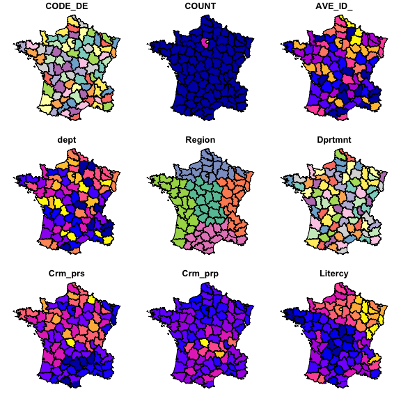

```r
plot(guerry_sf)
```

### 5.2 Create rgeoda object from `sf`

`sf` package makes it easy to work with geospatial data. It also provides functions to do basic spatial data analysis. `rgeoda` provides helper function `sf_to_geoda` to create a GeoDa instance from a `sf` object. Users can then call GeoDa functions to do further spatial data analysis.

Create a geoda object from the sf object guerry_sp you just created.

```r
library(rgeoda)

guerry_gda <- sf_to_geoda(guerry_sf)
```

rgeoda uses wkb, which is a binary representation of geometries, to exchange data between sf and libgeoda in memory.

By default, sf_to_geoda() only using geometries to create a geoda object, which is fast and user can reuse the data.frame from the sf object to do analysis. This function has an optional parameter with_table, to allow user to use both geometries and data.frame to create a geoda object by calling, for example: sp_to_geoda(guerry_sp, with_table=TRUE)

### 5.3 ESDA with rgeoda

Now, with the geoda object guerry, you can call rgeoda’s spatial analysis functions. For example, to examine the local Moran statistics of variable “crm_prs” (Population per Crime against persons):

```r
queen_w <- queen_weights(guerry_gda)

guerry_df <- as.data.frame(guerry_sf)
crm_prs <- guerry_df['Crm_prs'][,1]
```

#### 5.3.1 Local Moran Map

```r
lisa <- local_moran(queen_w, crm_prs)
```

Now, with the LISA results, we can do exploratory spatial data analysis by generating a LISA cluster map:

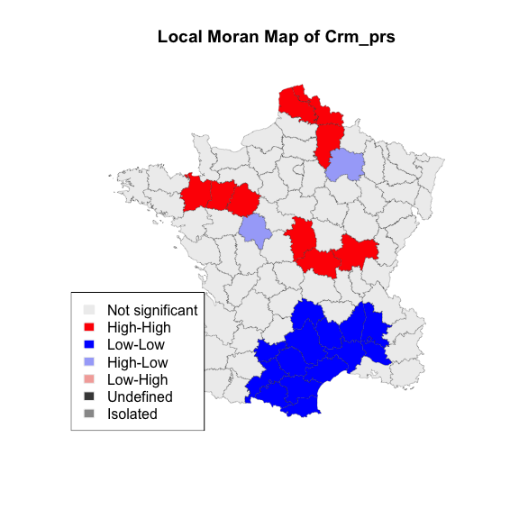

```r
lisa_colors <- lisa_colors(lisa)
lisa_labels <- lisa_labels(lisa)
lisa_clusters <- lisa_clusters(lisa)

plot(st_geometry(guerry_sf),
     col=sapply(lisa_clusters, function(x){return(lisa_colors[[x+1]])}),
     border = "#333333", lwd=0.2)
title(main = "Local Moran Map of Crm_prs")
legend('bottomleft', legend = lisa_labels, fill = lisa_colors, border = "#eeeeee")
```

From the above code, you can see that we still use `sf` object to do plotting. The values of cluster indicators from `rgeoda`’s `LISA` object are used to make the LISA map.

You can easily append the lisa results to original `sf` object by manipulating the data.frame object inside the `sf` object.

```r
guerry_sf$moran_cluster <- lisa_clusters
```

```r
lisa_clusters
```

```
##  [1] 0 1 1 0 0 2 0 2 0 2 2 0 0 2 0 0 1 0 0 0 0 0 0 2 0 0 0 2 2 0 0 2 1 0 3 0 0 0
## [39] 0 0 0 0 0 0 0 2 0 0 3 0 1 0 0 0 0 0 1 0 0 1 0 0 0 2 0 0 0 0 1 1 0 0 0 0 0 0
## [77] 2 2 0 2 0 0 0 0 0
```

To create a siginificant map that is associated with the Local Moran map:

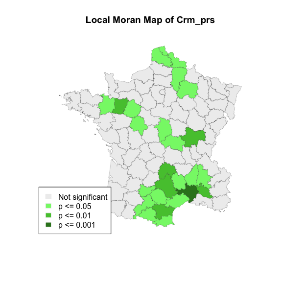

```r
lisa_p <- lisa_pvalues(lisa)
p_labels <- c("Not significant", "p <= 0.05", "p <= 0.01", "p <= 0.001")
p_colors <- c("#eeeeee", "#84f576", "#53c53c", "#348124")
plot(st_geometry(guerry_sf),
     col=sapply(lisa_p, function(x){
       if (x <= 0.001) return(p_colors[4])
       else if (x <= 0.01) return(p_colors[3])
       else if (x <= 0.05) return (p_colors[2])
       else return(p_colors[1])
       }),
     border = "#333333", lwd=0.2)
title(main = "Local Moran Map of Crm_prs")
legend('bottomleft', legend = p_labels, fill = p_colors, border = "#eeeeee")
```